# GET00203 - Estatística Computacional 1

Aula 15 - Teste de hipótese para comparação de médias de 3 ou mais populações

[Rafael Erbisti](https://sites.google.com/site/rerbisti)

### Análise de Variância (ANOVA)

O **teste de hipótese para comparação de médias de 3 ou mais populações** é realizado usando a **análise de variância (ANOVA)**. O objetivo é determinar se há diferenças significativas entre as médias de três ou mais grupos.

- **Hipótese nula ($H_0$)**: Todas as médias populacionais são iguais.
  $$H_0: \mu_1 = \mu_2 = \mu_3 = \dots = \mu_k$$
- **Hipótese alternativa ($H_1$)**: Pelo menos uma média é diferente.
  $$H_1: \text{Pelo menos um } \mu_i \text{ é diferente.}$$

#### Estatística de Teste

A estatística de teste é a razão $F$ da **distribuição $F$**:

$$F = \frac{\text{Variância entre os grupos}}{\text{Variância dentro dos
grupos}}$$

##### Variância entre os grupos (variabilidade explicada):

Mede a diferença entre as médias dos grupos e a média geral:
$$\text{SQentre} = \sum_{i=1}^k n_i (\bar{X}_i - \bar{X})^2$$

##### Variância dentro dos grupos (variabilidade não explicada):

Mede a variação dentro de cada grupo:
$$\text{SQdentro} = \sum_{i=1}^k \sum_{j=1}^{n_i} (X_{ij} - \bar{X}_i)^2$$

A estatística $F$ é então calculada como:
$$F = \frac{\frac{\text{SQentre}}{k-1}}{\frac{\text{SQdentro}}{N-k}}$$

Onde:

- $k$: número de grupos.
- $N$: número total de observações.

#### Passos do Teste

1. **Calcular a soma de quadrados**:
   - Soma de quadrados entre ($\text{SQentre}$).
   - Soma de quadrados dentro ($\text{SQdentro}$).
   - Soma de quadrados total ($\text{SQtotal} = \text{SQentre} + \text{SQdentro}$).
2. **Calcular os graus de liberdade**:
   - Graus de liberdade entre: $k-1$.
   - Graus de liberdade dentro: $N-k$.
3. **Calcular o valor de $F$**: Usando as fórmulas acima.
4. **Comparar com o valor crítico de $F$**:
   - Obtenha o valor crítico na tabela $F$ para $(k-1, N-k)$ graus de liberdade e nível de significância $\alpha$.
   - Ou calcule o **p-valor** correspondente.
5. **Tomar a decisão**:
   - Se $F$ observado > $F$ crítico (ou $p < \alpha$), rejeitar $H_0$.

#### Suposições da ANOVA

Para que o teste seja válido, as seguintes suposições devem ser atendidas:

1. As populações têm distribuições normais.
2. As variâncias das populações são iguais (homogeneidade de variâncias).
3. As observações são independentes.

##### Exemplo 1

Vamos utilizar o conjunto de dados `PlantGrowth` do `R`. Esses dados fornece o peso de plantas cultivadas sob duas condições de tratamento distintas e uma condição de controle.

```r
# Obtendo os dados
data = PlantGrowth
sample_n(data,10)
```

```
   weight group
1    4.17  trt1
2    5.17  ctrl
3    5.33  ctrl
4    4.53  ctrl
5    5.14  ctrl
6    4.81  trt1
7    5.12  trt2
8    5.26  trt2
9    6.15  trt2
10   4.89  trt1
```

A coluna `group` é definida como um fator, enquanto as diferentes categorias (*ctr*, *trt1*, *trt2*) são chamadas de níveis do fator. Os níveis são listados em ordem alfabética.

```r
levels(data$group)
```

```
[1] "ctrl" "trt1" "trt2"
```

Calculando estatísticas resumo por grupos (contagem, média e desvio padrão):

```r
tab = data |>
  group_by(group) |>
  summarise(quantidade = n(),
            media = mean(weight, na.rm = TRUE),
            desvio_padrao = sd(weight, na.rm = TRUE))

knitr::kable(tab)
```

| group | quantidade | media | desvio_padrao |
| --- | --- | --- | --- |
| ctrl | 10 | 5.032 | 0.5830914 |
| trt1 | 10 | 4.661 | 0.7936757 |
| trt2 | 10 | 5.526 | 0.4425733 |

Também podemos realizar análises descritivas básicas, como gráficos box-plot para visualização da distribuição dos dados por grupo.

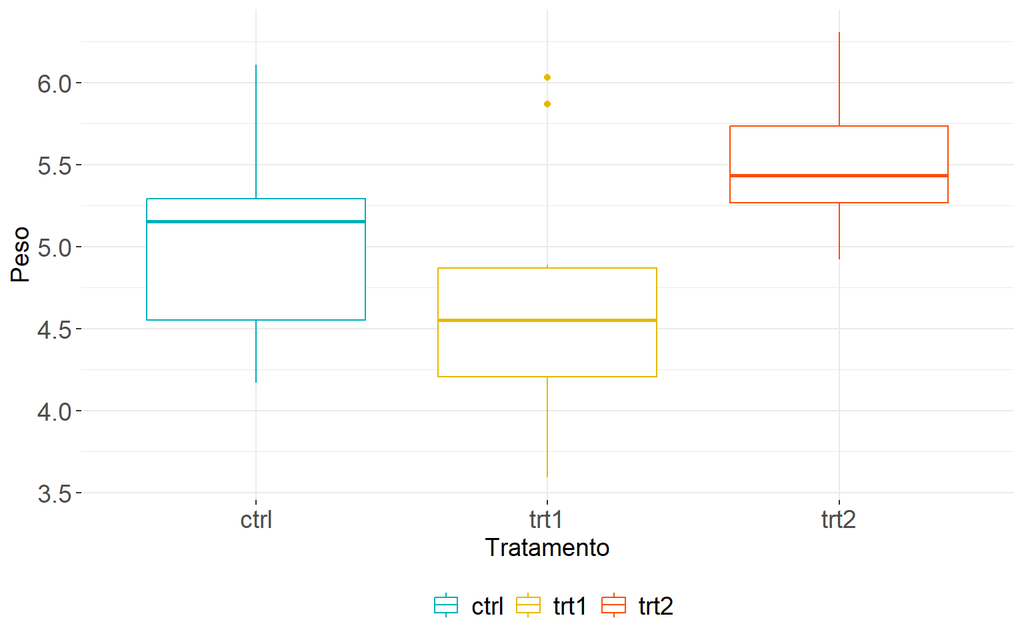

```r
ggplot(data, aes(x = factor(group, levels = c("ctrl", "trt1", "trt2")), y = weight, color = group)) +
  geom_boxplot() +
  scale_color_manual(values = c("#00AFBB", "#E7B800", "#FC4E07")) +
  labs(x = "Tratamento", y = "Peso") +
  theme_bw() +
  theme(axis.title = element_text(size = 14),
        axis.text = element_text(size = 14),
        legend.position = "bottom",
        legend.text = element_text(size = 14),
        legend.title = element_blank(),
        panel.border = element_blank())
```

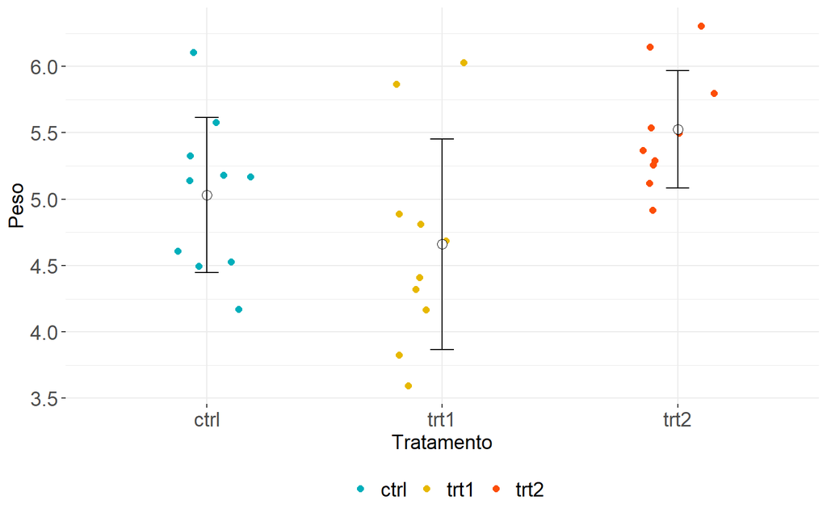

```r
ggplot() +
  geom_jitter(data = data, aes(x = factor(group, levels = c("ctrl", "trt1", "trt2")), y = weight, color = group), width = 0.2, size = 2) +
  geom_point(data = tab, aes(x = group, y = media), size = 3, shape = 21, fill = "white") +
  geom_errorbar(data = tab, aes(x = group, ymin = media - desvio_padrao, ymax = media + desvio_padrao), width = 0.1) +
  labs(x = "Tratamento", y = "Peso") +
  scale_color_manual(values = c("#00AFBB", "#E7B800", "#FC4E07")) +
  theme_bw() +
  theme(axis.title = element_text(size = 14),
        axis.text = element_text(size = 14),
        legend.position = "bottom",
        legend.text = element_text(size = 14),
        legend.title = element_blank(),
        panel.border = element_blank())
```

Queremos verificar se os pesos médios das plantas nas três condições experimentais variam significativamente, isto é, queremos testar as seguintes hipóteses
$$H_0: \mu_{ctrl} = \mu_{trt1} = \mu_{trt2} \\
H_1: \text{Pelo menos um } \mu_i \text{ é diferente.}$$
Essa teste pode ser respondido usando a função `aov()` do `R`, que realiza a análise de variância (ANOVA).

```r
# ANOVA
res.aov = aov(weight ~ group, data = data)
summary(res.aov)
```

```
            Df Sum Sq Mean Sq F value Pr(>F)
group        2  3.766  1.8832   4.846 0.0159 *
Residuals   27 10.492  0.3886
---
Signif. codes:  0 '***' 0.001 '**' 0.01 '*' 0.05 '.' 0.1 ' ' 1
```

As colunas `F value` e `Pr(>F)` na saída correspondem ao valor da estatística de teste F e ao p-valor do teste, respectivamente.

Podemos concluir que existem diferenças significativas entre os grupos destacados com “*” no resumo do modelo, uma vez que o p-valor foi menor do que o nível de significância estabelecido de 5%.

### Comparações múltiplas entre médias de grupos

Um p-valor significativo implica que algumas (ou alguma) das médias dos grupos são diferentes em no teste ANOVA apresentado acima, porém, não sabemos quais pares de grupos são diferentes.

Neste caso, é interessante realizar comparações múltiplas entre pares para verificar se as diferenças médias entre certos pares de grupos são estatisticamente significativas.

#### Comparações múltiplas de Tukey entre pares

Podemos calcular o Tukey HSD (Tukey Honest Significant Differences) para realizar várias comparações entre as médias dos grupos, quando o teste ANOVA é significativo.

De fato, este teste realiza comparações múltiplas entre todas as médias dos grupos e testa as seguintes hipóteses:

- *Hipótese nula ($H_0$)*: Para cada par de grupos $i$ e $j$, a diferença entre as médias dos grupos é igual a zero. Ou seja, não há diferença significativa entre os grupos.

$$H_0: \mu_i = \mu_j$$
onde $\mu_i$ e $\mu_j$ são as médias dos grupos $i$ e $j$, respectivamente.

- *Hipótese alternativa ($H_1$)*: Para cada par de grupos $i$ e $j$, a diferença entre as médias não é igual a zero. Ou seja, existe uma diferença significativa entre as médias dos grupos.

$$H_1: \mu_i \neq \mu_j$$

No `R`, a ANOVA ajustada é passada para a função `TukeyHSD()` como entrada e o teste Tukey é realizado.

```r
TukeyHSD(res.aov)
```

```
  Tukey multiple comparisons of means
    95% family-wise confidence level

Fit: aov(formula = weight ~ group, data = data)

$group
            diff        lwr       upr     p adj
trt1-ctrl -0.371 -1.0622161 0.3202161 0.3908711
trt2-ctrl  0.494 -0.1972161 1.1852161 0.1979960
trt2-trt1  0.865  0.1737839 1.5562161 0.0120064
```

com **lwr**, **upr** sendo os pontos inferior e superior do intervalo de confiança a 95% (padrão) da diferença entre o par de médias, respectivamente; e **p adj** o p-valor após o ajuste para comparações múltiplas.

Utilizando os dados do exemplo anterior, somente a diferença entre *trt2* e *trt1* é significativa, conforme mostrado pela saída, com um p-valor ajustado de 0,012.

#### Teste t pareado

As hipóteses testadas também avaliam a igualdade ou não das médias de cada par de grupos, como apresentado acima para o teste de Tukey.

No `R`, a função `pairwise.t.test()` é utilizada para realizar testes t pareados entre todos os pares possíveis de grupos.

```r
pairwise.t.test(data$weight, data$group, p.adjust.method = "BH")
```

```
    Pairwise comparisons using t tests with pooled SD

data:  data$weight and data$group

     ctrl  trt1
trt1 0.194 -
trt2 0.132 0.013

P value adjustment method: BH
```

Utilizando os dados do exemplo anterior, este teste também confirma que há diferença significativa somente entre *trt2* e *trt1*, cujo p-valor ajustado foi de 0,013.

**Observação**: esses métodos de correção (ajuste) para múltiplas comparações fazem correções nos p-valores a fim de evitar erros do tipo I (rejeitar uma hipótese nula verdadeira), uma vez que esse risco aumenta à medida que o número de testes cresce.

> **Desafio 1:** Simule uma amostra de tamanho 200 de uma população $N(25,9)$, considerando que as 30 primeiras observações pertencem ao Grupo 1, as 40 seguintes pertencem ao Grupo 2, as próximas 50 ao Grupo 3 e as últimas 80 ao Grupo 4. Verifique se a média dos grupos é igual.

> **Desafio 2:** Simule uma amostra de tamanho 30 de uma população normal com média 40 e variância 10. Simule outra amostra de tamanho 50 de uma população $N(50,10)$. Simule uma terceira amostra de tamanho 40 de uma população $N(48,10)$. Simule mais uma amostra de tamanho 30 de uma população normal com média 42 e variância 10. Faça um boxplot para comparar a distribuição das quatro amostras geradas e comente. Avalie, formalmente, se as média dessas populações diferem. Caso não sejam iguais, identifique qual (ou quais) médias são diferentes.